# Clustering approach and MCMC practicalities of stochastic block models

Clement Lee

2019-06-13 (Thu)

# 1. Introduction

## Background

- Review paper on ArXiv: 1903.00114
- Models for clustering graphs/networks
  1. Type of graph
  2. Inference approach
  3. Clustering approach
  4. Number of groups / model selection
  5. Longitudinal modelling?
- More recent experience

## A Bigger Picture

#### Three main types of models for networks

1. Generative models
   - Preferential attachment model (Barabasi and Albert, 1999)
   - Small world model (Watts and Strogatz, 1998)
2. Exponential random graph models
3. Latent models
   - Stochastic block models (SBMs)
   - Latent feature models (Miller, Griffiths and Jordan, 2009; Morup, Schmidt and Hansen, 2011)
   - Latent class analysis models (Ng and Murphy, 2018)
   - Latent space models (Hoff, Raftery and Handcock, 2002; Handcock, Raftery and Tantrum, 2007)

## Stochastic Block Models

- Clustering nodes in topological space
- Each node belongs to one group (for now)
- Structural equivalence
  - Connectivity of nodes in one group with any group is **similar**
  - Not necessarily **high** (within the same group) or **low** (with another group)
- Different from community detection

## Notation

- Undirected graph: $~\mathcal{G}$
- Number of nodes: $~n$
- Adjacency matrix: $~\boldsymbol{Y}:=\{\boldsymbol{Y}_{pq}\}_{n\times{}n}$
- Number of groups: $~K$
- Membership of node $p$, if it belongs to group $i$:
  - $\boldsymbol{Z}_p=(\underbrace{0~\cdots~0}_{(i-1)}~1~\underbrace{0~\cdots~0}_{(K-i)})^T$
  - Instead of $\boldsymbol{Z}_p=i$
- All memberships: $\boldsymbol{Z}:=(\boldsymbol{Z}_1~\boldsymbol{Z}_2\cdots~\boldsymbol{Z}_n)^T$
  - $n\times{}K$ matrix
  - $\boldsymbol{Z}_{pi}=1$
- Block matrix: $~\boldsymbol{C}:=\{\boldsymbol{C}_{ij}\}_{K\times{}K}$

## Structural Equivalence

- The edge probability of two nodes depends on their groups only, given the groups
- For nodes $p$ and $q$, $\Pr(\boldsymbol{Y}_{pq}=1|~p\text{ in group }i,q\text{ in group }j)=\boldsymbol{C}_{ij}$
- Equivalently, $\Pr(\boldsymbol{Y}_{pq}=1|~\boldsymbol{Z}_p,\boldsymbol{Z}_q)=\boldsymbol{Z}_p^T\boldsymbol{C}\boldsymbol{Z}_q$
- Likelihood:
  $$f(\boldsymbol{Y}|\boldsymbol{Z},\boldsymbol{C})=\prod_{p<q}\left[\left(\boldsymbol{Z}_p^T\boldsymbol{C}\boldsymbol{Z}_q\right)^{\boldsymbol{Y}_{pq}}\left(1-\boldsymbol{Z}_p^T\boldsymbol{C}\boldsymbol{Z}_q\right)^{(1-\boldsymbol{Y}_{pq})}\right]$$

## Bayesian Inference

- Prior of $\boldsymbol{Z}_p$: multinomial$(\boldsymbol{\theta})$
  - Independence between nodes
  - $\boldsymbol{\theta}$ also a $K$-vector
- Prior of $\boldsymbol{\theta}$: Dirichlet$(\alpha)$
- Prior of $\boldsymbol{C}$: $\boldsymbol{C}_{ij}\overset{\text{i.i.d.}}{\sim}\text{Beta}(\boldsymbol{A}_{ij},\boldsymbol{B}_{ij})$
  - $\boldsymbol{A}$ & $\boldsymbol{B}$ also $K\times{}K$ matrices
- Prior of $\alpha$: Gamma$(a,b)$
- Posterior:
  $$\pi(\boldsymbol{Z},\boldsymbol{\theta},\boldsymbol{C},\alpha|\boldsymbol{Y})\propto\pi(\boldsymbol{Y},\boldsymbol{Z},\boldsymbol{\theta},\boldsymbol{C},\alpha)\\
  = f(\boldsymbol{Y}|\boldsymbol{Z},\boldsymbol{C})\times\pi(\boldsymbol{Z}|\boldsymbol{\theta})\times\pi(\boldsymbol{\theta}|\alpha)\times\pi(\boldsymbol{C})\times\pi(\alpha)$$

## MCMC Algorithms

- Algorithmic simplicity: regular Gibbs sampler
  - Parameter (except $\alpha$) & latent variables updated via individual Gibbs steps
- Integrating $\boldsymbol{C}$ out: collapsed Gibbs sampler
  - Similar to Griffiths and Steyvers (2004) for topic modelling
- Computational efficiency:
  - Morup, Schmidt and Hansen (2011)
  - Li, Ahn and Welling (2016)

# 2. Soft Clustering

## Comparing Models

- Hard clustering
  - $\boldsymbol{Z}_p=(0~\cdots~0~1~0~\cdots~0)^T$
  - Only one $1$, all others zeros
- Latent feature model
  - $\boldsymbol{Z}_p=(1~\cdots~0~1~1~\cdots~0)^T$
  - Can have multiple $1$’s
- Soft clustering
  - $\boldsymbol{Z}_p=(0.2~\cdots~0.0~~0.5~~0.3~\cdots~0.0)^T$
  - Non-negative weights sum to 1

## Mixed Membership SBM

#### Airoldi, Blei, Fienberg and Xing (2008)

- Node $p$ can belong to different groups when interacting with different nodes
  - Potentially two different groups as far as $\boldsymbol{Y}_{pq}$ and $\boldsymbol{Y}_{pr}$ are concerned $(r\neq{}q)$
- $\boldsymbol{Z}_{pq}$ corresponds to each possible *dyad* $(p,q)$ instead of each *node*
- $\boldsymbol{Z}$ now an $n\times{}n\times{}K$ array of latent variables
- $\boldsymbol{\theta}_p$: group weights for node $p$, $K$-vector
  - i.i.d., Dirichlet$(\alpha)$ distribution
- $\boldsymbol{\Theta} := (\boldsymbol{\theta}_1~\boldsymbol{\theta}_2~\cdots~\boldsymbol{\theta}_n)^T$
  - $n\times{}K$ matrix

## Likelihood & Inference

- Edge probability: $\Pr(\boldsymbol{Y}_{pq}=1|\boldsymbol{Z}_{pq},\boldsymbol{Z}_{qp})=\boldsymbol{Z}_{pq}^T\boldsymbol{C}\boldsymbol{Z}_{qp}$
- Posterior:
  $$\pi(\boldsymbol{Z},\boldsymbol{\Theta},\boldsymbol{C},\alpha|\boldsymbol{Y})\propto\pi(\boldsymbol{Y},\boldsymbol{Z},\boldsymbol{\Theta},\boldsymbol{C},\alpha)\\
  = f(\boldsymbol{Y}|\boldsymbol{Z},\boldsymbol{C})\times\pi(\boldsymbol{Z}|\boldsymbol{\Theta})\times\pi(\boldsymbol{\Theta}|\alpha)\times\pi(\boldsymbol{C})\times\pi(\alpha)$$
- Very similar to hard clustering version
- Why not commonly used?

## Comparing with Clustering Non-relational Data

#### Latent Dirichlet Allocation (for example)

- $O(n)$
- Collapsed Gibbs sampler
  - Parameters can be integrated out

#### Mixed membership SBM

- $O(n^2)$ because of the dimensions of $\boldsymbol{Z} (n\times{}n\times{}K)$
- Collapsed Gibbs sampler?
  - $\boldsymbol{C}$ and $\boldsymbol{D}$ can be integrated out
  - Statistically simpler, computationally (much) less efficient

## Going Back to the Basics?

- Hard: $\boldsymbol{Z}_p$ is the membership
- Soft: $\boldsymbol{\theta}_p$ is the mixed membership
  - $\boldsymbol{Z}$ could be integrated out
  - Inefficient without data augmentation

## Some Modifications

#### To the model

- Assortative mixed membership SBM: Gopalan et al. (2012)
  - Connectivity high within and low between groups
  - Number of parameters in $\boldsymbol{C}$ reduced from $K^2$ to $K+1$
- For directed acyclic graph: Lee and Wilkinson (2018)
  - An extra parameter as the topological order of the nodes
  - Number of latent variables halved compared to the original version for directed graphs

#### To the MCMC algorithm

- Stochastic Gradient MCMC: Li, Ahn and Welling (2016)
  - Sub-sampling a graph

# 3. Back to Hard Clustering

## Poisson Approximation

#### Previously (Bernoulli SBM)

- $\boldsymbol{Y}_{pq}|\boldsymbol{Z},\boldsymbol{C}\sim\text{Bernoulli}(\boldsymbol{Z}_p^T\boldsymbol{C}\boldsymbol{Z}_q)$
- $\boldsymbol{Z}_p$ is the membership and cannot be integrated out

#### Karrer and Newman(2011); Peixoto (2018)

- $\boldsymbol{Y}_{pq}|\boldsymbol{Z},\boldsymbol{C}\sim\text{Poisson}(\boldsymbol{Z}_p^T\boldsymbol{C}\boldsymbol{Z}_q)$
- Support of $\boldsymbol{C}_{ij}$ no longer $[0,1]$
- $\boldsymbol{C}_{ij}|\boldsymbol{Z},\mu\sim\text{Exp}\left(\frac{\boldsymbol{N}_i\boldsymbol{N}_j}{\mu}\right)$
  - $\boldsymbol{N}_i$: the size of group $i$
  - $\mu$: extra scalar parameter

## Comparing the Priors

#### Bernoulli SBM

- $\pi(\boldsymbol{Z},\boldsymbol{C},\boldsymbol{\theta},\alpha)=\pi(\boldsymbol{Z}|\boldsymbol{\theta})~\pi(\boldsymbol{\theta}|\alpha)~\pi(\boldsymbol{C})~\pi(\alpha)$
- Block matrix $\boldsymbol{C}$ independent of latent variables $\boldsymbol{Z}$

#### Poisson SBM

- $\pi(\boldsymbol{Z},\boldsymbol{C},\mu)=\pi(\boldsymbol{C}|\boldsymbol{Z},\mu)~\pi(\boldsymbol{Z})~\pi(\mu)$
- Block matrix $\boldsymbol{C}$ depends on latent variables $\boldsymbol{Z}$ (and $\mu$)

## Integrating out $\boldsymbol{C}$

- Likelihood:
  $$f(\boldsymbol{Y}|\boldsymbol{Z},\mu)=\int{}f(\boldsymbol{Y}|\boldsymbol{C},\boldsymbol{Z},\mu)\pi(\boldsymbol{C}|\boldsymbol{Z},\mu)d\boldsymbol{C}\\=\int\left[\prod_{p,q}(\boldsymbol{Z}_p^T\boldsymbol{C}\boldsymbol{Z}_q)^{\boldsymbol{Y}_{pq}}\exp(-\boldsymbol{Z}_p^T\boldsymbol{C}\boldsymbol{Z}_q)(\boldsymbol{Y}_{pq}!)^{-1}\times\prod_{i,j}\frac{\boldsymbol{N}_i\boldsymbol{N}_j}{\mu}\exp\left(-\frac{\boldsymbol{N}_i\boldsymbol{N}_j}{\mu}\boldsymbol{C}_{ij}\right)\right]d\boldsymbol{C}\\=\cdots=\frac{\prod_{i,j}\boldsymbol{E}_{ij}!}{\prod_{p,q}\boldsymbol{Y}_{pq}!\prod_{i}\boldsymbol{N}_i^{\boldsymbol{E}_{i\cdot}+\boldsymbol{E}_{\cdot{}i}}}\times\frac{\mu^m}{(1+\mu)^{m+K^2}}$$
- Edge matrix: $\boldsymbol{E}:=\{\boldsymbol{E}_{ij}\}_{K\times{}K}$
- Total number of edges: $m$
- $\boldsymbol{Z}$ influences the likelihood through $\boldsymbol{N}$ and $\boldsymbol{E}$

## Inference

- Further integrating $\mu$ out:
  $$f(\boldsymbol{Y}|\boldsymbol{Z})=\int{}f(\boldsymbol{Y}|\boldsymbol{Z},\mu)\pi(\mu)d\mu\\=\frac{\prod_{i,j}\boldsymbol{E}_{ij}!}{\prod_{p,q}\boldsymbol{Y}_{pq}!\prod_{i}\boldsymbol{N}_i^{\boldsymbol{E}_{i\cdot}+\boldsymbol{E}_{\cdot{}i}}}\times\underbrace{\int\frac{\mu^m}{(1+\mu)^{m+K^2}}\pi(\mu)d\mu}_{\text{1-dim integration}}$$
- Posterior:
  $$\pi(\boldsymbol{Z}|\boldsymbol{Y})\propto\underbrace{\pi(\boldsymbol{Y},\boldsymbol{Z})=f(\boldsymbol{Y}|\boldsymbol{Z})\pi(\boldsymbol{Z})}_{\text{Integrated Complete Likelihood (ICL)}}$$

## Prior of $\boldsymbol{Z}$

- Once we specify $\boldsymbol{Z}$’s prior, we are able to not only do inference but also calculate ICL
- If $\boldsymbol{Z}$ is known, so are $\boldsymbol{N}$ and $\boldsymbol{E}$
- Instead of directly assigning a prior, Peixoto (2018) put an SBM on $\boldsymbol{E}$
  - Treating the edge matrix as the adjacency matrix one level up
  - Nested/hierarchical SBM

## Summary of SBMs

|  | **Bernoulli** | **Mixed membership** | **Poisson** |
| --- | --- | --- | --- |
| Clustering | Hard | Soft | Hard |
| Quantity of interest | $\boldsymbol{Z}$ | $\boldsymbol{\Theta}$ | $\boldsymbol{Z}$ |
| Marginalisation? | $\boldsymbol{C}$ | $\boldsymbol{C}$ & $\boldsymbol{D}$, or $\boldsymbol{Z}$ | $\boldsymbol{C}$ & $\mu$ |
| Remarks |  | Neither marginalisation particularly useful | Exponential priors for $\boldsymbol{C}$ with dep. on $\boldsymbol{Z}$ |
|  |  | Quadratic computational cost | Can extend to nested version |

# 4. Practicalities

## Component-wise Moves

#### Metropolis

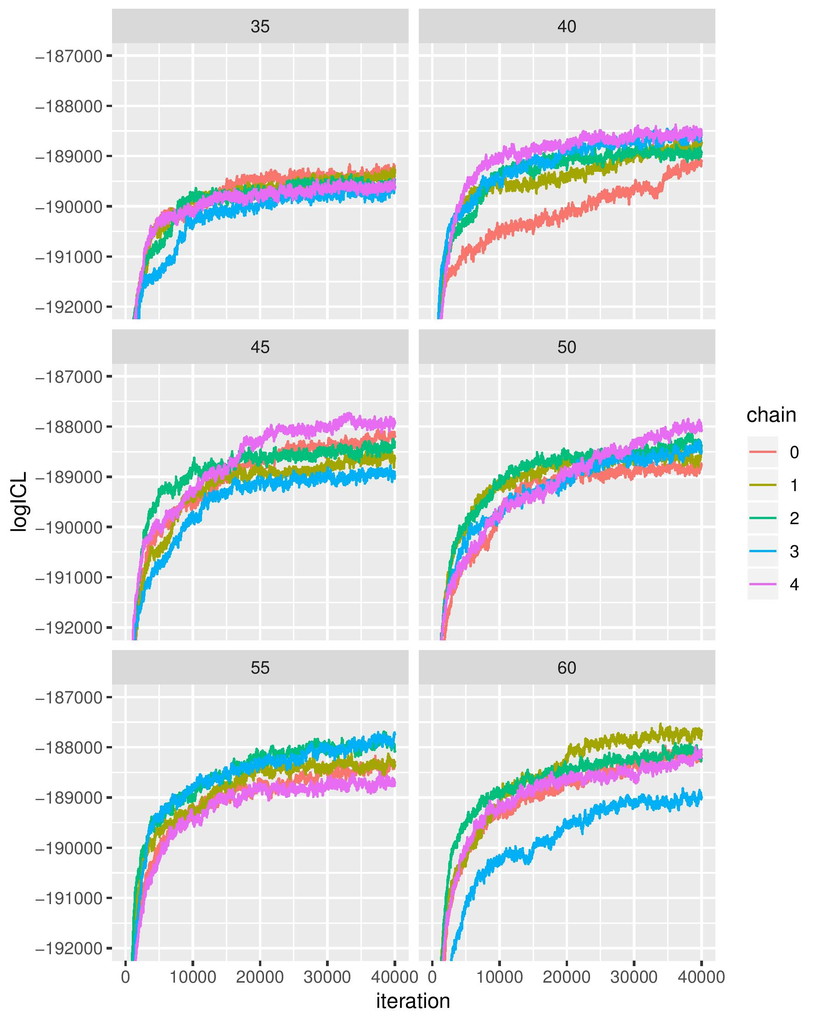

## Component-wise Moves

#### Gibbs

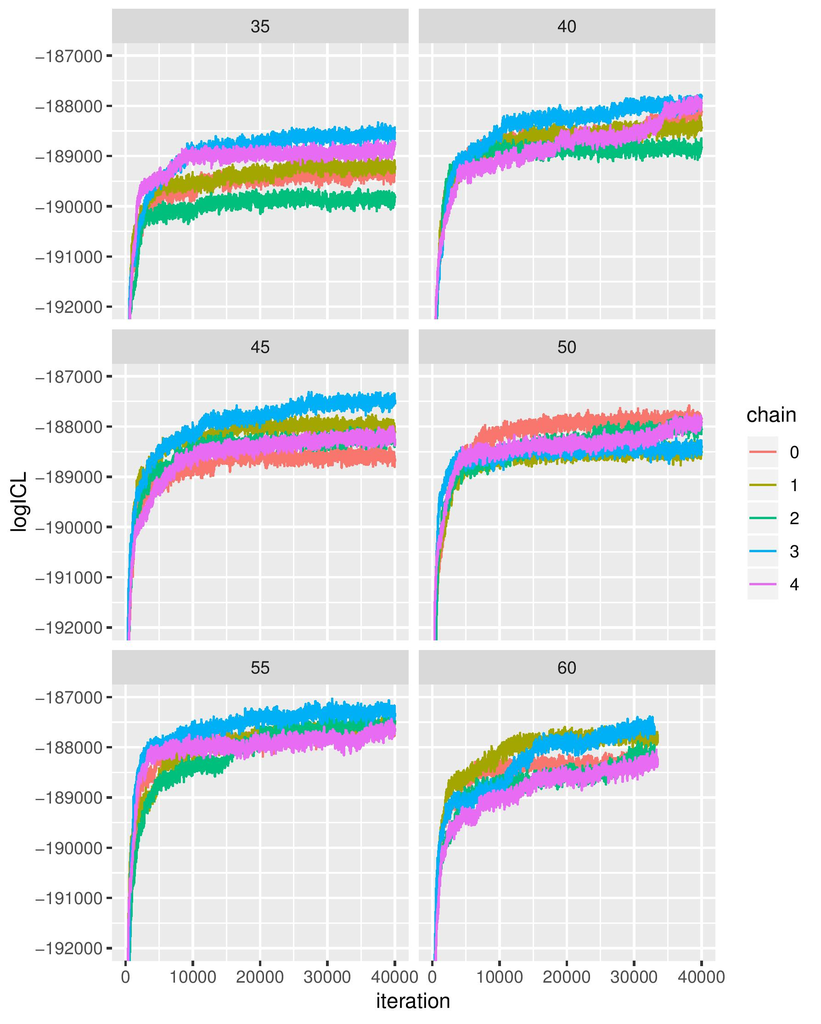

## Bigger Moves

#### Gibbs + M3 (McDaid, Murphy, Friel and Hurley, 2013)

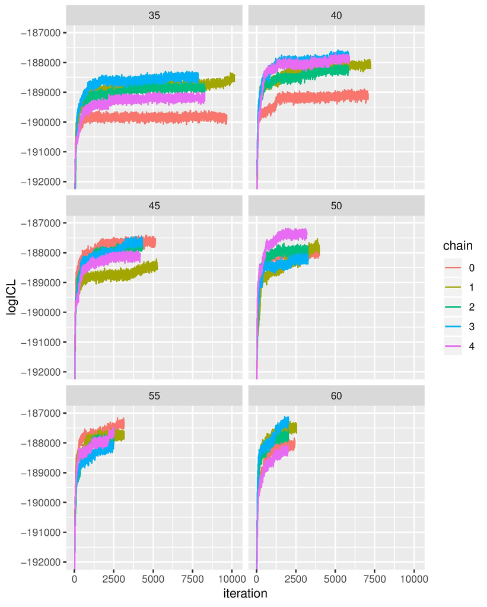

## M3 & Label Switching

#### Propose to randomise nodes in two groups

1. All nodes are placed in a randomly reordered list
2. Each node is placed in one group according to some assignment probability
3. Nobile and Fearnside (2007): Choose the ratio of the assignment probabilities as the ratio of the two posterior probabilities resulting from the assignments of the previous nodes
   - Heuristic, should lead to “good” choices
4. The same list traversed to calculate reverse proposal probability
5. Check agreement between current and proposed $\boldsymbol{Z}$; switch labels if agreement < 50%

## Informed Proposals

#### Zanella (2019)

- Incorporate local information on discrete spaces
- Similar to gradient-based methods for continuous spaces
- Not directly useful - struggle to move across well-separated modes

## Model Selection / K

#### Modelled

- Dirichlet process (Morup, Schmidt and Hansen, 2011)
- Indian buffet process for latent feature models (Miller, Griffiths and Jordan, 2009)

#### Estimated

- Allow merging, adding or deleting groups in MCMC
- McDaid, Murphy, Friel and Hurley (2013); Peixoto (2018)

#### Criterion

- BIC: Airoldi, Blei, Fienberg and Xing (2008)
- Perplexity: DuBois, Butts and Smyth (2013)
- ICL: Come and Latouche (2015); Matias and Miele (2017)

## Model Selection / K

#### Criterion: marginal likelihood

$$f(\boldsymbol{Y})=\frac{f(\boldsymbol{Y}|\boldsymbol{Z})\pi(\boldsymbol{Z})}{\pi(\boldsymbol{Z}|\boldsymbol{Y})}$$
$$\log{}f(\boldsymbol{Y})=\underbrace{\log\left[f(\boldsymbol{Y}|\boldsymbol{Z})\pi(\boldsymbol{Z})\right]}_{\text{log-ICL}} - \log\pi(\boldsymbol{Z}|\boldsymbol{Y})$$

- $\log\pi(\boldsymbol{Z}|\boldsymbol{Y})$ can be estimated (e.g. Ritter and Tanner, 1992)
- Can be computed offline
- Less unscalable than methods by Chib (1995), Chib and Jeliazkov (2001)
- Power posterior (Friel and Pettitt, 2008)?

## Summary

#### Next steps

- Hopefully component-wise Gibbs + M3 + (MC)$^3$ will work
- Compute marginal likelihood